# Build a Cohort of Language Learners

Amy Anderson

2024-04-09

#### Building the machinery for the social learning of multilingualism

The goal of this script is to generate a cohort of individuals who learn languages from each other in a multilingual space, in such a way that every individual develops a realistic language biography of whatever languages they are exposed to. This should form the basis of more complicated, age-structured, multi-generational models of the evolutionary dynamics of multilingualism.

```r
### Load libraries
library(tidyverse)
library(purrr)

# Load bespoke functions
source('./Functions/Pair agents for conversations.R')
```

```r
# Set Cohort size
N = 100

# Define the languages vector
languages <- c("A", "B", "C")

# Set number of years to run simulation
tmax = 74
```

#### Vertical Inheritance

Just to get things, started, have every individual in the cohort inherit a language from each of their parents. If both parents pass on the same language, then this individual begins life as a monolingual. If each parent passes on a different language, then this individual begins life as a bilingual.

```r
# Create a pool of languages to populate the parent generation
trait_pool <- sample(languages, N, replace = TRUE)
# Generate a random uniform distribution of languages in the parent generation
mother_tongue = sample(trait_pool, size = N, replace = TRUE)
father_tongue = sample(trait_pool, N, replace = TRUE)



# Create a function to assign inherited languages to each agent
assign_languages <- function(i) {
  # Create a language bank for each agent
  agent_languages <- lapply(languages, function(lang) vector(mode = "list", length = 1))
  names(agent_languages) <- languages

  # Inherit languages from parents
  for (j in seq(agent_languages)) {
    if (mother_tongue[i] == names(agent_languages[j]) | father_tongue[i] == names(agent_languages[j])) {
      agent_languages[[j]][1] <- 1
    }
    else(agent_languages[[j]][1] <- 0)
  }

  return(agent_languages)
}


agents <- 1:N
names(agents) <- agents
# Apply the function to each individual
language_bank <- lapply(agents, assign_languages)
```

#### Set the rate of language acquisition as an age-dependent function:

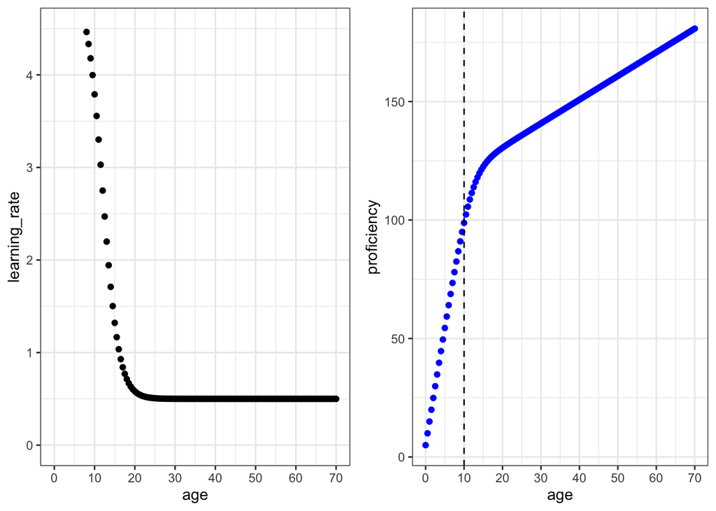

```r
library(cowplot)
# generate a sample of 1,000 people with a uniform distribution of ages 0-70 years.
ages <- seq(from = 0, to = 70, by = 0.5)
ppl <- data.frame(age = sample(ages, 1000, replace = TRUE))


language_rate <- function(x, params){
  params$r0 * (1 - (1 / (1 + exp(-params$a * (x - params$tc - params$d))))) + 0.5
}



acquisition_rates <- data.frame(r0 = 4.5, # starting rate at age = 0
                                a = 0.5, # steepness of sigmoidal decay rate
                                d = 12, # x-axis position of sigmoidal curve's center
                                tc = 0) # starting age of language exposure


# calculate language acquisition rates for simulated people as a function of age
ppl$learning_rate <- sapply(ppl$age, language_rate, params = acquisition_rates)

# calculate predicted language proficiency at each age (cumulative sum of learning rate)
ppl <- ppl %>%
  arrange(age) %>%
  unique() %>%
  mutate(proficiency = cumsum(learning_rate))


rate_plot <- ggplot(ppl, aes(x = age, y = learning_rate)) +
  geom_point() +
  scale_y_continuous(limits = c(0, 4.5)) +
  scale_x_continuous(breaks = c(0, 10, 20, 30, 40, 50, 60, 70)) +
  theme_bw()

prof_plot <- ggplot(ppl, aes(x = age, y = proficiency)) +
  geom_point(color = "blue") +
  geom_vline(xintercept = 10, linetype = 2) +
  scale_x_continuous(breaks = c(0, 10, 20, 30, 40, 50, 60, 70)) +
  theme_bw()


plot_grid(rate_plot, prof_plot, ncol = 2)
```

#### To have agents learn from each other:

- Every tick of model time, agents are paired at random.
- Each agent chooses (at random) to speak one of the languages in their language bank.
- If their interlocutor speaks a language that is new to them, that language is added to their bank.
- If they already know the language spoken by their interlocutor, then their proficiency in that language increases
- The amount that language proficiency increases is moderated by the agent’s age.

The function below will **update the language bank** for every individual in the cohort based on their interaction with another agent.

```r
### Define a FUNCTION to update everyone's language bank across multiple years of model time, as a function of age and social exposure to language.

update_language_bank <- function(language_bank, pairing = "random", tmax, speaking = FALSE) {
  language_list <- list()
  for (t in seq(tmax)) { # for each new year in model time
    if (pairing == "random") {
      pair <- pair_agents_randomly(length(language_bank)) # pick conversational partners
    }
    for (pair_row in seq_len(nrow(pair))) {
      speaker1 <- pair[pair_row, 1]
      speaker2 <- pair[pair_row, 2]


      # Identify the languages currently known by each agent
      speaker1_languages <- names(purrr::keep(language_bank[[speaker1]], function(x) all(x > 0)))
      speaker2_languages <- names(purrr::keep(language_bank[[speaker2]], function(x) all(x > 0)))

      # Each speaker picks a language to speak —- sampled at random from each individual's language bank
      speaker1_says <- sample(speaker1_languages, 1)
      speaker2_says <- sample(speaker2_languages, 1)

      # The amount of proficiency gained is a function of the listener's age.
      age_factor <- 100^(1/(t + 0.5))

      ### Learning by Listening ###
      # If speaker2 recognizes the language spoken by speaker1, then exposure to it improves their proficiency
      if (speaker1_says %in% speaker2_languages) {
        language_bank[[speaker2]][[speaker1_says]][t + 1] <- modify_depth(language_bank[[speaker2]][[speaker1_says]][t], 1, ~ .x + age_factor)
      }
        else {
        # Add the new language as a named vector in speaker2's language bank
        language_bank[[speaker2]][[speaker1_says]][t + 1] <- 1
      }

      # If speaker1 recognizes the language spoken by speaker2, then exposure to it improves their proficiency
      if (speaker2_says %in% speaker1_languages) {
        language_bank[[speaker1]][[speaker2_says]][t + 1] <- modify_depth(language_bank[[speaker1]][[speaker2_says]][t], 1, ~ .x + age_factor)
      }
       else {
        # Add the new language as a named vector in speaker1's language bank
        language_bank[[speaker1]][[speaker2_says]][t + 1] <- 1
      }

      if(speaking == FALSE){ #   If speaker1 does not recognize the language spoken by speaker2,
     # update all languages in speaker1's language bank (except the one spoken by speaker2)
     # to maintain their proficiency levels from time t to t+1
         for (lang in languages) {
    if (lang != speaker2_says) {
      language_bank[[speaker1]][[lang]][t + 1] <- language_bank[[speaker1]][[lang]][t]
    }
           if(lang != speaker1_says){
               language_bank[[speaker2]][[lang]][t + 1] <- language_bank[[speaker2]][[lang]][t]
               }
             }
           }

 ### Learning by Speaking ###
      if(speaking == TRUE){
        language_bank[[speaker1]][[speaker1_says]][t + 1] <- modify_depth(language_bank[[speaker1]][[speaker1_says]][t], 1, ~ .x + age_factor)
        language_bank[[speaker2]][[speaker2_says]][t + 1] <- modify_depth(language_bank[[speaker2]][[speaker2_says]][t], 1, ~ .x + age_factor)

     for (lang in languages) {
    if (lang != speaker2_says & lang != speaker1_says) {
      language_bank[[speaker1]][[lang]][t + 1] <- language_bank[[speaker1]][[lang]][t]
            language_bank[[speaker2]][[lang]][t + 1] <- language_bank[[speaker2]][[lang]][t]
           }
         }
     }
  }
  }
    return(language_bank)
}



### Trial run of model function
starting_bank <- lapply(agents, assign_languages) # initial language bank, tracking all languages inherited vertically by infants in the cohort of agents
test <- update_language_bank(starting_bank, tmax = 20) # test run: 20 years of language learning
```

#### Design an output table for population-level results: What % of the cohort knows each language at time t?

The code below that creates a summary table was written by ChatGPT.  
It runs, but it’s not particularly efficient. Something to optimize for future, if desired.

```r
# Define a function to summarize language bank at each time point: e.g., Number of speakers of language A at time t
count_speakers <- function(language_bank,
                           proficiency_threshold) {
  # Initialize an empty list to store summaries
  summary_list <- list()

  # Iterate over each time point
  for (t in seq_along(language_bank[[1]][[1]])) {
    # Initialize an empty data frame to store summary at current time point
    summary_df <- data.frame(Time = t)

    # Iterate over each language
    languages <- names(language_bank[[1]])
    for (lang in languages) {
      # Calculate count of agents with values > chosen proficiency threshold for current language at current time point
      count <- sum(map_lgl(language_bank, ~ .x[[lang]][t] > proficiency_threshold))

      # Add count to summary data frame
      summary_df[[lang]] <- count
    }

    # Append summary data frame to the summary list
    summary_list[[t]] <- summary_df
  }

  # Combine all summary data frames into a single data frame
  summary_table <- do.call(rbind, summary_list)

  return(summary_table)
}
```

Function to Plot number of speakers of each language over time:

```r
library(wesanderson)

plot_speakers <- function(language_bank, proficiency){
  tables <- data.frame()
for(i in seq(proficiency)){
  summary_table <- count_speakers(language_bank, proficiency_threshold = proficiency[i]) # apply count_speakers function defined above
  summary_table$proficiency <- paste("proficiency >", proficiency[i], sep = " ")
  tables <- rbind(tables, summary_table)
}

speakers_plot <- pivot_longer(tables, cols = c(-"Time", -"proficiency"), names_to = "Language", values_to = "Speakers") %>%
  ggplot(aes(x = Time, y = Speakers)) +
  geom_line(aes(color = Language)) +
  facet_wrap(~ proficiency) +
  scale_color_manual(values = wes_palette("Darjeeling1", type = "discrete")) +
  theme_minimal()
return(speakers_plot)
}
```

Run some models with different parameters:

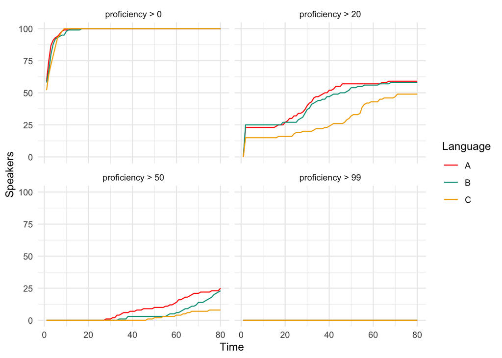

```r
just_listen <- update_language_bank(starting_bank, pairing = "random", tmax = 79, speaking = FALSE)

proficiency <- c(0, 20, 50, 99)
plot_speakers(just_listen, proficiency)
```

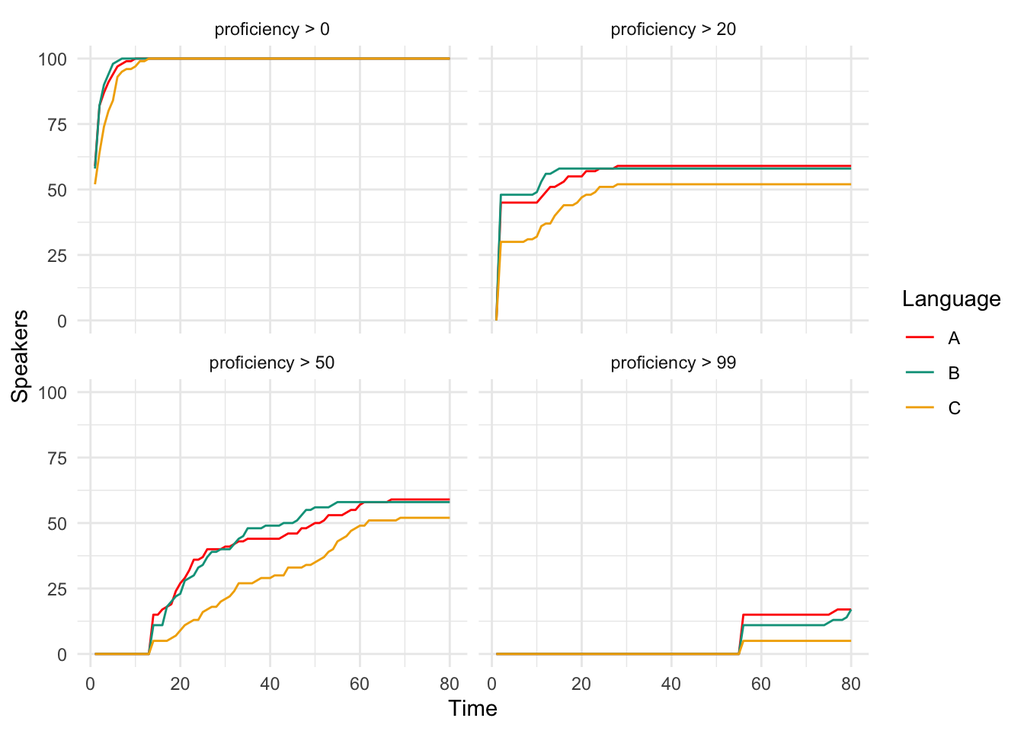

```r
listen_and_speak <- update_language_bank(starting_bank, pairing = "random", tmax = 79, speaking = TRUE)
plot_speakers(listen_and_speak, proficiency)
```

#### Plotting language biographies

[output not shown]

[figure not shown]

[output not shown]

[figure not shown]

```r
df %>%
  filter(agent_ID %in% 1:25) %>%
ggplot(aes(x = age, y = proficiency)) +
  geom_line(aes(color = languages)) +
  facet_wrap(~ agent_ID) +
  theme_bw() +
  theme(legend.position = "top")
```

[output not shown]